# Lab 6

Briana Barajas

2023-03-01

## Case Study: Eel Distribution Modeling

This week’s lab follows a project modeling the eel species *Anguilla australis* described by Elith et al. (2008). There are two data sets for this lab. You’ll use one for training and evaluating your model, and you’ll use your model to make predictions predictions on the other. Then you’ll compare your model’s performance to the model used by Elith et al.

```r
library(tidyverse)
library(tidymodels)
library(here)
library(gt)
library(vip)
```

## Data

Grab the training data sets (eel.model.data.csv, eel.eval.data.csv) from github here: https://github.com/MaRo406/eds-232-machine-learning/blob/main/data

```r
# read in data
eel_mod <- read_csv(here(data_dir, "eel.model.data.csv")) %>%
  select(-Site) %>%
  mutate(Method = as.factor(Method),
         Angaus = as.factor(Angaus))

eel_eval <- read_csv(here(data_dir, "eel.eval.data.csv")) %>%
  rename(Angaus = Angaus_obs) %>%
  mutate(Method = as.factor(Method),
         Angaus = as.factor(Angaus))
```

### Split and Resample

Split the model data (`eel.model.data.csv`) into a training and test set, stratified by outcome score (Angaus). Use 10-fold CV to resample the training set.

```r
set.seed(125)

# split model data
eel_split <- initial_split(eel_mod, strata = Angaus)
eel_train <- training(eel_split)
eel_test <- testing(eel_split)

# define number cv folds
cv_folds <- vfold_cv(eel_train, v = 10)
```

### Preprocess

Create a recipe to prepare your data for the XGBoost model

```r
# create recipe
recip <- recipe(Angaus~., data = eel_train) %>%
  step_dummy(all_nominal_predictors()) %>%
  step_normalize(all_numeric_predictors())
```

## Tuning XGBoost

### Tune Learning Rate

Following the XGBoost tuning strategy outlined in lecture, first we conduct tuning on just the `learning_rate` parameter:

1. Create a model specification using {xgboost} for the estimation
- Only specify one parameter to tune()
2. Set up a grid to tune your model by using a range of learning rate parameter values: `expand.grid(learn_rate = seq(0.0001, 0.3, length.out = 30))`
- Use appropriate metrics argument(s) - Computational efficiency becomes a factor as models get more complex and data get larger. Record the time it takes to run. Do this for each tuning phase you run.You could use {tictoc} or `system.time()`.
3. Show the performance of the best models and the estimates for the learning rate parameter values associated with each.

```r
set.seed(125)

## ==================================================
##                1. Create Model Spec           ----
## ==================================================
# create xgboost model specifications
xgb_spec1 <- boost_tree(learn_rate = tune()) %>%
  set_engine("xgboost", nthread = 2) %>%
  set_mode("classification")

# create workflow
xgb_workflow1 <- workflow() %>%
  add_model(xgb_spec1) %>%
  add_recipe(recip)


## ==================================================
##                 2. Set Up Grid                ----
## ==================================================

# set up grid
system.time(

  xgb_cv_tune1 <- xgb_workflow1 %>%
    tune_grid(resamples = cv_folds,
              grid = expand.grid(learn_rate = seq(0.0001, 0.3, length.out = 30)))

) # END system.time
```

```
##    user  system elapsed
##   8.285   0.013   8.388
```

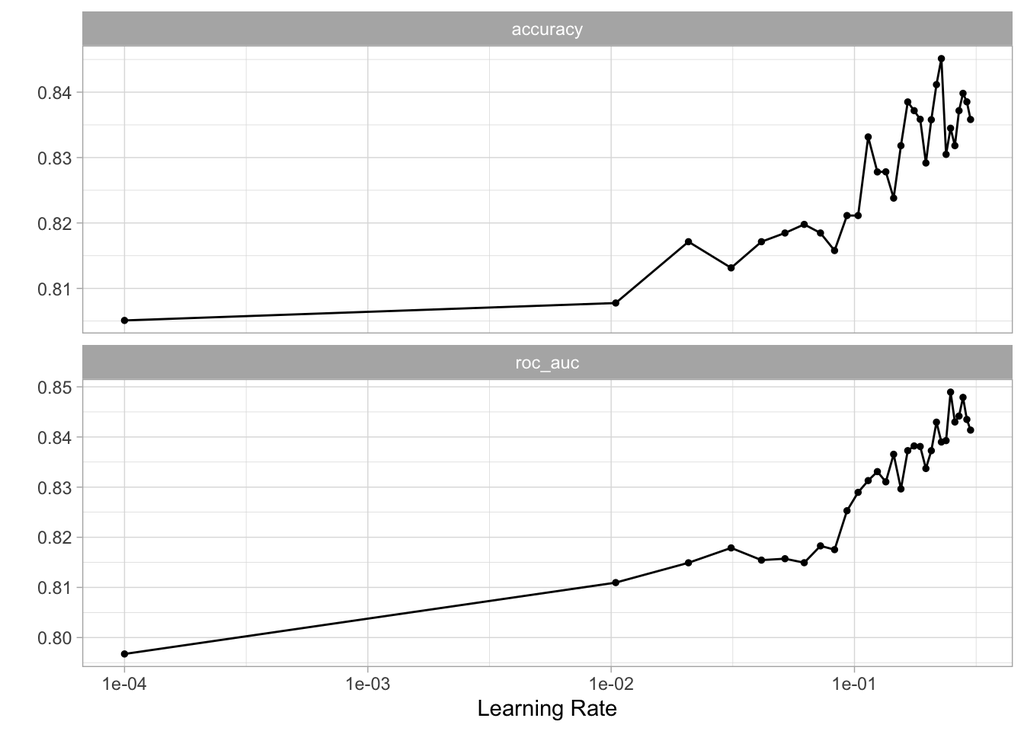

```r
## ==================================================
##            3. Best Model Performance          ----
## ==================================================
# view model performance & estimates of learning rate
autoplot(xgb_cv_tune1) + theme_light()
```

```r
# show top 5 values of learning rate
show_best(xgb_cv_tune1, n = 5, metric = "accuracy") %>% gt()
```

| learn_rate | .metric | .estimator | mean | n | std_err | .config |
| --- | --- | --- | --- | --- | --- | --- |
| 0.2276103 | accuracy | binary | 0.8451351 | 10 | 0.009962052 | Preprocessor1_Model23 |
| 0.2172690 | accuracy | binary | 0.8411532 | 10 | 0.010555244 | Preprocessor1_Model22 |
| 0.2793172 | accuracy | binary | 0.8398198 | 10 | 0.011372559 | Preprocessor1_Model28 |
| 0.2896586 | accuracy | binary | 0.8385225 | 10 | 0.011245765 | Preprocessor1_Model29 |
| 0.1655621 | accuracy | binary | 0.8385045 | 10 | 0.009125653 | Preprocessor1_Model17 |

### Tune Tree Parameters

1. Create a new specification where you set the learning rate (which you already optimized) and tune the tree parameters.
2. Set up a tuning grid. This time use `grid_latin_hypercube()` to get a representative sampling of the parameter space
3. Show the performance of the best models and the estimates for the tree parameter values associated with each.

```r
set.seed(125)

## ==================================================
##                1. Update Model Spec           ----
## ==================================================
# isolate best value for learning rate
best_learn_rate <- select_best(xgb_cv_tune1, metric = "accuracy")
best_learn_rate <- as.numeric(best_learn_rate$learn_rate)

# update model specifications to include tree parameter
xgb_spec2 <- boost_tree(learn_rate = best_learn_rate,
                        trees = 3000,
                        tree_depth = tune(),
                        min_n = tune(),
                        loss_reduction = tune()) %>%
  set_engine("xgboost", nthread = 2) %>%
  set_mode("classification")

# isolate parameters
xgb_param2 <- xgb_spec2 %>% extract_parameter_set_dials()

# create workflow with updated specs
xgb_workflow2 <- workflow() %>%
  add_model(xgb_spec2) %>%
  add_recipe(recip)

## ==================================================
##          2. Tune with latin-hyper-cube        ----
## ==================================================

system.time(

  xgb_cv_tune2 <- xgb_workflow2 %>%
    tune_grid(resamples = cv_folds,
              grid = grid_latin_hypercube(x = xgb_param2, size = 10))

) # END system.time
```

```
##    user  system elapsed
##  74.736   0.321  75.765
```

```r
## ==================================================
##          3. Best Model Performance            ----
## ==================================================

# show top performing model accuracies
# autoplot(xgb_cv_tune2) + theme_light()

show_best(xgb_cv_tune2, n = 5, metric = "accuracy") %>% gt()
```

| min_n | tree_depth | loss_reduction | .metric | .estimator | mean | n | std_err | .config |
| --- | --- | --- | --- | --- | --- | --- | --- | --- |
| 29 | 12 | 7.429069e-03 | accuracy | binary | 0.8265405 | 10 | 0.01532353 | Preprocessor1_Model10 |
| 26 | 2 | 2.652266e-06 | accuracy | binary | 0.8251712 | 10 | 0.01446433 | Preprocessor1_Model01 |
| 3 | 13 | 4.403348e-09 | accuracy | binary | 0.8171351 | 10 | 0.01100547 | Preprocessor1_Model03 |
| 40 | 8 | 1.494621e+00 | accuracy | binary | 0.8158559 | 10 | 0.01541886 | Preprocessor1_Model08 |
| 36 | 15 | 2.566424e-10 | accuracy | binary | 0.8091892 | 10 | 0.01396633 | Preprocessor1_Model07 |

### Tune Stochastic Parameters

1. Create a new specification where you set the learning rate and tree parameters (which you already optimized) and tune the stochastic parameters.
2. Set up a tuning grid. Use `grid_latin_hypercube()` again.
3. Show the performance of the best models and the estimates for the tree parameter values associated with each.

**NOTE:** `mtry` is a stochastic parameter

```r
set.seed(125)

## ==================================================
##                1. Update Model Spec           ----
## ==================================================
# isolate best value for tree parameters
best_tree_param <- select_best(xgb_cv_tune2, metric = "accuracy")
best_min_n <- as.numeric(best_tree_param$min_n)
best_tree_depth <- as.numeric(best_tree_param$tree_depth)
best_loss_reduction <- as.numeric(best_tree_param$loss_reduction)

# create updated specifications
xgb_spec3 <- boost_tree(learn_rate = best_learn_rate,
                        trees = 3000,
                        tree_depth = best_tree_depth,
                        min_n = best_min_n,
                        loss_reduction = best_loss_reduction,

                        mtry = tune(),
                        sample_size = tune()) %>%
  set_engine("xgboost", nthread = 2) %>%
  set_mode("classification")

# isolate parameters
xgb_param3 <- xgb_spec3 %>% extract_parameter_set_dials()

# create workflow with updated specs
xgb_workflow3 <- workflow() %>%
  add_model(xgb_spec3) %>%
  add_recipe(recip)

## ==================================================
##          2. Tune with latin-hyper-cube        ----
## ==================================================

system.time(

  xgb_cv_tune3 <- xgb_workflow3 %>%
    tune_grid(resamples = cv_folds,
              grid = grid_latin_hypercube(finalize(xgb_param3, x = eel_train),
                size = 10))

) # END system.time
```

```
##    user  system elapsed
##  43.867   0.303  44.672
```

```r
## ==================================================
##          3. Best Model Performance            ----
## ==================================================

# show top performing model accuracies
# autoplot(xgb_cv_tune3) + theme_light()

show_best(xgb_cv_tune3, n = 5, metric = "accuracy") %>% gt()
```

| mtry | sample_size | .metric | .estimator | mean | n | std_err | .config |
| --- | --- | --- | --- | --- | --- | --- | --- |
| 3 | 0.9958968 | accuracy | binary | 0.8238559 | 10 | 0.01568116 | Preprocessor1_Model05 |
| 12 | 0.8348998 | accuracy | binary | 0.8131712 | 10 | 0.01368406 | Preprocessor1_Model06 |
| 7 | 0.5889442 | accuracy | binary | 0.8118559 | 10 | 0.01660532 | Preprocessor1_Model02 |
| 11 | 0.8169156 | accuracy | binary | 0.8105225 | 10 | 0.01305411 | Preprocessor1_Model07 |
| 2 | 0.5413557 | accuracy | binary | 0.8065405 | 10 | 0.01973099 | Preprocessor1_Model09 |

## Finalize workflow and make final prediction

1. How well did your model perform? What types of errors did it make?

```r
set.seed(125)

# finalize the workflow
final_wf <- finalize_workflow(xgb_workflow3, select_best(xgb_cv_tune3, metric = "accuracy"))

# fit the model to the training data
xgb_fit <- fit(final_wf, eel_train)

# make final prediction using test data
eel_predict <- predict(object = xgb_fit, new_data = eel_test) %>%
  bind_cols(eel_test)

# collect and view metrics
metrics <- as.data.frame(accuracy(eel_predict, truth = Angaus,
                                  estimate = .pred_class))
metrics %>% gt()
```

| .metric | .estimator | .estimate |
| --- | --- | --- |
| accuracy | binary | 0.8007968 |

**ANS:** The model had an accuracy of 0.800, meaning that 80% of predictions were accurate. After browsing through the predictions, it seems that the model is more likely to predict the species is present when it isn’t. In terms of estimating species absence, the model appeared to work better.

## Fit your model the evaluation data and compare performance

1. Now used your final model to predict on the other dataset (eval.data.csv)
2. How does your model perform on this data?
3. How do your results compare to those of Elith et al.?
- Use {vip} to compare variable importance
- What do your variable importance results tell you about the distribution of this eel species?

```r
set.seed(125)

## ==================================================
##              1. Predict on Eval Data          ----
## ==================================================
# make predictions using model and evaluation data
eval_eel_predict <- predict(object = xgb_fit, new_data = eel_eval) %>%
  bind_cols(eel_eval)

## ==================================================
##               2. Model Performance            ----
## ==================================================
# collect and view metrics
metrics_final <- as.data.frame(accuracy(eval_eel_predict, truth = Angaus,
                                  estimate = .pred_class))
metrics_final %>% gt()
```

| .metric | .estimator | .estimate |
| --- | --- | --- |
| accuracy | binary | 0.798 |

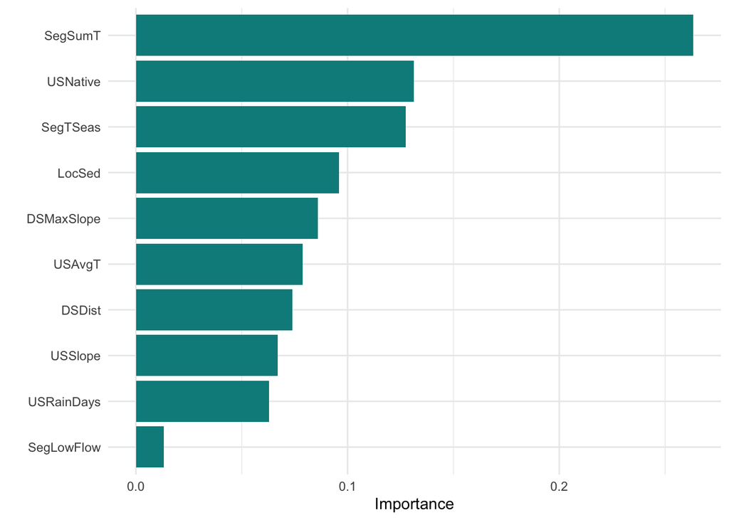

```r
## ==================================================
##               3. Variable Importance          ----
## ==================================================
xgb_fit %>% vip(geom = "col",
                       aesthetics = list(fill = "darkcyan")) +
  theme_minimal()
```